# 431 Class 08

Thomas E. Love, Ph.D.

2024-09-19

## Today’s Agenda

- One-Factor Analysis of Variance
  - Using Regression to Develop an ANOVA model
  - Methods for pairwise multiple comparisons
  - Checking Model Assumptions
  - Bayesian fitting of an ANOVA model

## Load packages and set theme

```r
library(janitor)

library(readxl)   # to read in an .xlsx file

library(car)
library(rstanarm)
library(easystats)
library(tidyverse)

theme_set(theme_bw())
knitr::opts_chunk$set(comment = NA)

source("c08/data/Love-431.R") # for the lovedist() function
```

## Importing Data / Creating Factors

```r
ohio20 <- read_xlsx("c08/data/ohio_2020.xlsx") |>
  mutate(behavior = Hmisc::cut2(rk_behavior, g = 4),
         clin_care = Hmisc::cut2(rk_clin_care, g = 3)) |>
  mutate(behavior = fct_recode(behavior,
            "Best" = "[ 1,23)", "High" = "[23,45)",
            "Low" = "[45,67)", "Worst" = "[67,88]")) |>
  mutate(clin_care = fct_recode(clin_care,
            "Strong" = "[ 1,31)", "Middle" = "[31,60)",
            "Weak" = "[60,88]")) |>
  select(FIPS, state, county, outcomes, behavior, clin_care,
         everything())
```

## Any missing values?

```r
data_codebook(ohio20)
```

```
ohio20 (88 rows and 12 variables, 12 shown)

ID | Name         | Type        | Missings |          Values |           N
---+--------------+-------------+----------+-----------------+------------
1  | FIPS         | character   | 0 (0.0%) |           39001 |  1 (  1.1%)
   |              |             |          |           39003 |  1 (  1.1%)
   |              |             |          |           39005 |  1 (  1.1%)
   |              |             |          |           39007 |  1 (  1.1%)
   |              |             |          |           39009 |  1 (  1.1%)
   |              |             |          |           39011 |  1 (  1.1%)
   |              |             |          |           39013 |  1 (  1.1%)
   |              |             |          |           39015 |  1 (  1.1%)
   |              |             |          |           39017 |  1 (  1.1%)
   |              |             |          |           39019 |  1 (  1.1%)
   |              |             |          |           (...) |
---+--------------+-------------+----------+-----------------+------------
2  | state        | character   | 0 (0.0%) |            Ohio | 88 (100.0%)
---+--------------+-------------+----------+-----------------+------------
3  | county       | character   | 0 (0.0%) |           Adams |  1 (  1.1%)
   |              |             |          |           Allen |  1 (  1.1%)
   |              |             |          |         Ashland |  1 (  1.1%)
   |              |             |          |       Ashtabula |  1 (  1.1%)
   |              |             |          |          Athens |  1 (  1.1%)
   |              |             |          |        Auglaize |  1 (  1.1%)
   |              |             |          |         Belmont |  1 (  1.1%)
   |              |             |          |           Brown |  1 (  1.1%)
   |              |             |          |          Butler |  1 (  1.1%)
   |              |             |          |         Carroll |  1 (  1.1%)
   |              |             |          |           (...) |
---+--------------+-------------+----------+-----------------+------------
4  | outcomes     | numeric     | 0 (0.0%) |   [-2.05, 2.17] |          88
---+--------------+-------------+----------+-----------------+------------
5  | behavior     | categorical | 0 (0.0%) |            Best | 22 ( 25.0%)
   |              |             |          |            High | 22 ( 25.0%)
   |              |             |          |             Low | 22 ( 25.0%)
   |              |             |          |           Worst | 22 ( 25.0%)
---+--------------+-------------+----------+-----------------+------------
6  | clin_care    | categorical | 0 (0.0%) |          Strong | 30 ( 34.1%)
   |              |             |          |          Middle | 29 ( 33.0%)
   |              |             |          |            Weak | 29 ( 33.0%)
---+--------------+-------------+----------+-----------------+------------
7  | rk_behavior  | numeric     | 0 (0.0%) |         [1, 88] |          88
---+--------------+-------------+----------+-----------------+------------
8  | rk_clin_care | numeric     | 0 (0.0%) |         [1, 88] |          88
---+--------------+-------------+----------+-----------------+------------
9  | rural        | numeric     | 0 (0.0%) |     [0.58, 100] |          88
---+--------------+-------------+----------+-----------------+------------
10 | income       | numeric     | 0 (0.0%) | [40416, 103536] |          88
---+--------------+-------------+----------+-----------------+------------
11 | trump16      | numeric     | 0 (0.0%) |    [0.31, 0.81] |          88
---+--------------+-------------+----------+-----------------+------------
12 | somecollege  | numeric     | 0 (0.0%) |  [20.38, 85.07] |          88
--------------------------------------------------------------------------
```

## Outcomes by Behavior Groups

```r
ggplot(ohio20, aes(x = outcomes, y = behavior)) +
  geom_violin() +
  geom_boxplot(aes(fill = behavior), width = 0.2) +
  stat_summary(fun = mean, geom = "point",
               shape = 16, size = 3, col = "white") +
  scale_fill_metro_d() +
  guides(fill = "none") +
  labs(x = "Health Outcomes", y = "Behavior Group",
       title = "Health Outcomes by Behavior Group")
```

## Outcomes by Behavior Groups

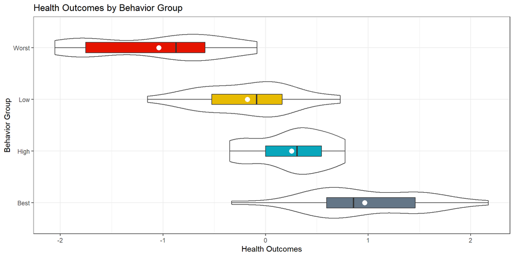

## Building the Linear Model

Do we see meaningful differences in population means of `outcomes` across `behavior` groups?

```r
model_one <- lm(outcomes ~ behavior, data = ohio20)

model_parameters(model_one, ci = 0.90)
```

```
Parameter        | Coefficient |   SE |         90% CI |  t(84) |      p
------------------------------------------------------------------------
(Intercept)      |        0.96 | 0.11 | [ 0.78,  1.15] |   8.74 | < .001
behavior [High]  |       -0.71 | 0.16 | [-0.97, -0.45] |  -4.55 | < .001
behavior [Low]   |       -1.14 | 0.16 | [-1.40, -0.88] |  -7.32 | < .001
behavior [Worst] |       -2.01 | 0.16 | [-2.27, -1.75] | -12.85 | < .001
```

## ANOVA Table

```r
anova(model_one)
```

```
Analysis of Variance Table

Response: outcomes
          Df Sum Sq Mean Sq F value    Pr(>F)
behavior   3 46.421 15.4736  57.718 < 2.2e-16 ***
Residuals 84 22.519  0.2681
---
Signif. codes:  0 '***' 0.001 '**' 0.01 '*' 0.05 '.' 0.1 ' ' 1
```

## Estimate Means with 90% CIs

```r
means_one <- estimate_means(model_one, ci = 0.90)

means_one
```

```
Estimated Marginal Means

behavior |  Mean |   SE |         90% CI
----------------------------------------
Best     |  0.96 | 0.11 | [ 0.78,  1.15]
High     |  0.25 | 0.11 | [ 0.07,  0.44]
Low      | -0.18 | 0.11 | [-0.36,  0.01]
Worst    | -1.04 | 0.11 | [-1.22, -0.86]

Marginal means estimated at behavior
```

### Plot the means

```r
plot(visualisation_recipe(means_one,
                show_data = c("violin", "jitter")))
```

## Estimate Means with 90% CIs

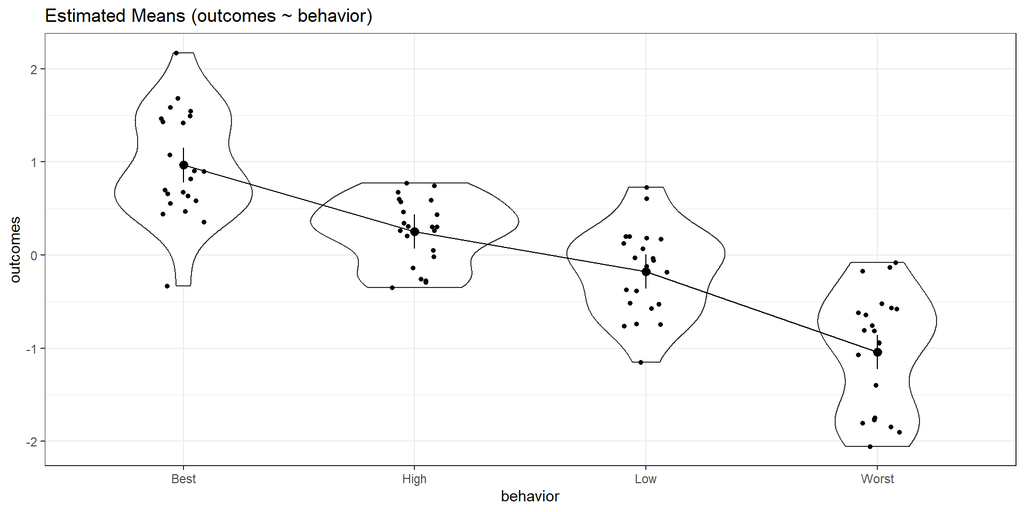

## What’s Left? (Multiple Comparisons)

- Can we identify pairwise comparisons of means that show meaningful differences?
- Can we build a confidence interval procedure that protects against Type I error expansion due to multiple comparisons?

## Two Methods for Multiple Comparisons

There are two (main) methods we’ll study to estimate the difference between specific pairs of means with uncertainty intervals, while dealing with the problem of multiple comparisons.

- Holm-Bonferroni pairwise comparisons
- Tukey’s HSD (Honestly Significant Differences) approach

Just for fun, we’ll use a 99% confidence level today.

## Compare `behavior` group means?

ANOVA suggests that the means aren’t likely to all be the same, but we really want to make pairwise comparisons…

```r
estimate_means(model_one, ci = 0.99)
```

```
Estimated Marginal Means

behavior |  Mean |   SE |         99% CI
----------------------------------------
Best     |  0.96 | 0.11 | [ 0.67,  1.26]
High     |  0.25 | 0.11 | [-0.04,  0.54]
Low      | -0.18 | 0.11 | [-0.47,  0.11]
Worst    | -1.04 | 0.11 | [-1.33, -0.75]

Marginal means estimated at behavior
```

For example, is Best meaningfully different from High?

## Could we just run a bunch of t tests?

This approach assumes that you need to make no adjustment for the fact that you are doing multiple comparisons, simultaneously.

```r
estimate_contrasts(model_one, ci = 0.99, p_adjust = "none")
```

```
Marginal Contrasts Analysis

Level1 | Level2 | Difference |       99% CI |   SE | t(84) |      p
-------------------------------------------------------------------
Best   |   High |       0.71 | [0.30, 1.12] | 0.16 |  4.55 | < .001
Best   |    Low |       1.14 | [0.73, 1.55] | 0.16 |  7.32 | < .001
Best   |  Worst |       2.01 | [1.59, 2.42] | 0.16 | 12.85 | < .001
High   |    Low |       0.43 | [0.02, 0.84] | 0.16 |  2.76 | 0.007
High   |  Worst |       1.29 | [0.88, 1.71] | 0.16 |  8.29 | < .001
Low    |  Worst |       0.86 | [0.45, 1.27] | 0.16 |  5.53 | < .001

Marginal contrasts estimated at behavior
p-values are uncorrected.
```

## The problem of Multiple Comparisons

- The more comparisons you do simultaneously, the more likely you are to make an error.

In the worst case scenario, suppose you do two tests - first A vs. B and then A vs. C, each at the 99% confidence level.

- What is the combined error rate across those two t tests?

## The problem of Multiple Comparisons

Run the first test. Make a Type I error 1% of the time.

| A vs B Type I error | Probability |
| --- | --- |
| Yes | 0.01 |
| No | 0.99 |

Now, run the second test. Assume (perhaps wrongly) that comparing A to C is independent of your A-B test result. What is the error rate now?

## The problem of Multiple Comparisons

Assuming there is a 1% chance of making an error in either test, independently …

| – | Error in A vs. C | No Error | Total |
| --- | --- | --- | --- |
| Type I error in A vs. B | 0.0001 | 0.0099 | 0.01 |
| No Type I error in A-B | 0.0099 | 0.9801 | 0.99 |
| Total | 0.01 | 0.99 | 1.00 |

So you will make an error in the A-B or A-C comparison **1.99%** of the time, rather than the nominal $\alpha = 0.01$ error rate.

## But we’re building SIX tests

1. Best vs. High
2. Best vs. Low
3. Best vs. Worst
4. High vs. Low
5. High vs. Worst
6. Low vs. Worst

and if they were independent, and each done at a 5% error rate, we could still wind up with an error rate of

$.05 + (.95)(.05) + (.95)(.95)(.05) + (.95)^3(.05) + (.95)^4(.05) + (.95)^5(.05)$ = .265

Or worse, if they’re not independent.

## The Bonferroni Method

If we do 6 tests, we could reduce the necessary $\alpha$ to 0.01 / 6 = 0.00167 and that maintains an error rate no higher than $\alpha = 0.01$ across the 6 tests.

## Better Approach: Holm-Bonferroni

Suppose you have $m$ comparisons, with p-values sorted from low to high as $p_1$, $p_2$, …, $p_m$.

- Is $p_1 < \alpha/m$? If so, reject $H_1$ and continue, otherwise STOP.
- Is $p_2 < \alpha/(m-1)$? If so, reject $H_2$ and continue, else STOP.
- and so on…

## Holm-Bonferroni Approach

This is uniformly more powerful than Bonferroni, while preserving the overall false positive rate at $\alpha$. It’s also the default choice of `estimate_contrasts()`.

```r
estimate_contrasts(model_one, ci = 0.99, p_adjust = "holm")
```

```
Marginal Contrasts Analysis

Level1 | Level2 | Difference |        99% CI |   SE | t(84) |      p
--------------------------------------------------------------------
Best   |   High |       0.71 | [ 0.20, 1.22] | 0.16 |  4.55 | < .001
Best   |    Low |       1.14 | [ 0.64, 1.65] | 0.16 |  7.32 | < .001
Best   |  Worst |       2.01 | [ 1.50, 2.51] | 0.16 | 12.85 | < .001
High   |    Low |       0.43 | [-0.08, 0.94] | 0.16 |  2.76 | 0.007
High   |  Worst |       1.29 | [ 0.79, 1.80] | 0.16 |  8.29 | < .001
Low    |  Worst |       0.86 | [ 0.36, 1.37] | 0.16 |  5.53 | < .001

Marginal contrasts estimated at behavior
p-value adjustment method: Holm (1979)
```

## Get the Holm results into a tibble

```r
con_holm <- estimate_contrasts(model_one, ci = 0.99, p_adjust = "holm")

con_holm_tib <- tibble(con_holm) |>
  mutate(contr = str_c(Level1, " - ", Level2))

con_holm_tib |> head()
```

```
# A tibble: 6 × 10
  Level1 Level2 Difference  CI_low CI_high    SE    df     t        p contr
  <chr>  <chr>       <dbl>   <dbl>   <dbl> <dbl> <dbl> <dbl>    <dbl> <chr>
1 Best   High        0.711  0.204    1.22  0.156    84  4.55 3.52e- 5 Best - Hi…
2 Best   Low         1.14   0.635    1.65  0.156    84  7.32 5.53e-10 Best - Low
3 Best   Worst       2.01   1.50     2.51  0.156    84 12.8  9.54e-21 Best - Wo…
4 High   Low         0.431 -0.0759   0.939 0.156    84  2.76 7.04e- 3 High - Low
5 High   Worst       1.29   0.787    1.80  0.156    84  8.29 7.87e-12 High - Wo…
6 Low    Worst       0.863  0.356    1.37  0.156    84  5.53 1.07e- 6 Low - Wor…
```

## Plot the Holm results

```r
ggplot(con_holm_tib, aes(x = contr, y = Difference)) +
  geom_point(size = 3, col = "purple") +
  geom_errorbar(aes(ymin = CI_low, ymax = CI_high)) +
  geom_hline(yintercept = 0, col = "red", lty = "dashed") +
  labs(title = "Holm 99% Intervals for Health Outcomes",
       x = "Contrast",
       y = "Difference in Health Outcomes Score")
```

## Plot the Holm results

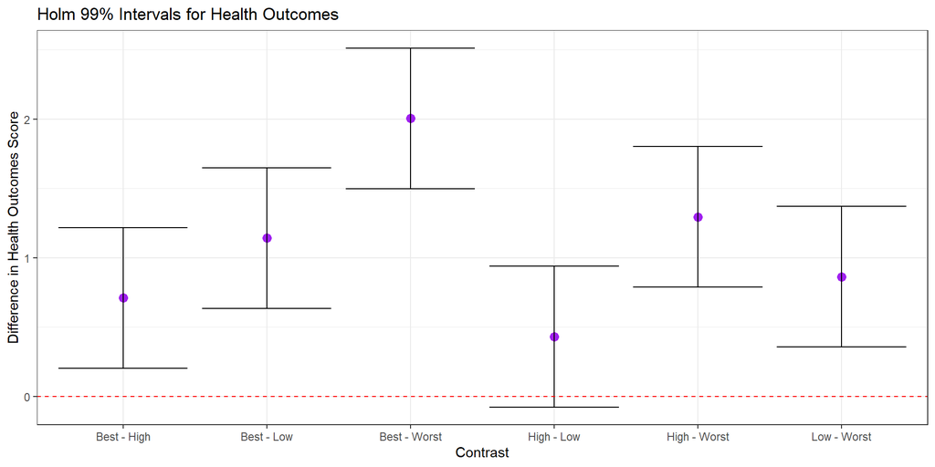

## Tukey’s HSD Intervals

Tukey’s HSD approach is a better choice for pre-planned comparisons with a balanced (or nearly balanced) design.

```r
estimate_contrasts(model_one, ci = 0.99, p_adjust = "tukey")
```

```
Marginal Contrasts Analysis

Level1 | Level2 | Difference |        99% CI |   SE | t(84) |      p
--------------------------------------------------------------------
Best   |   High |       0.71 | [ 0.21, 1.21] | 0.16 |  4.55 | < .001
Best   |    Low |       1.14 | [ 0.64, 1.64] | 0.16 |  7.32 | < .001
Best   |  Worst |       2.01 | [ 1.50, 2.51] | 0.16 | 12.85 | < .001
High   |    Low |       0.43 | [-0.07, 0.93] | 0.16 |  2.76 | 0.035
High   |  Worst |       1.29 | [ 0.79, 1.80] | 0.16 |  8.29 | < .001
Low    |  Worst |       0.86 | [ 0.36, 1.36] | 0.16 |  5.53 | < .001

Marginal contrasts estimated at behavior
p-value adjustment method: Tukey
```

## Plot Tukey Intervals

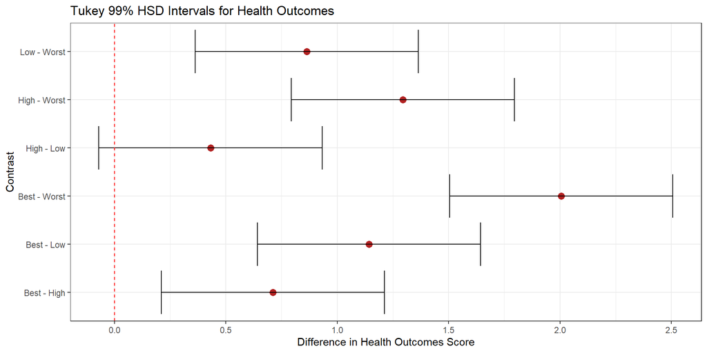

## ANOVA Assumptions

The assumptions behind analysis of variance are those of a linear model. Of specific interest are:

- The samples obtained from each group are independent.
- Ideally, the samples from each group are a random sample from the population described by that group.
- In the population, the variance of the outcome in each group is equal. (This is less of an issue if our study involves a balanced design.)
- In the population, we have Normal distributions of the outcome in each group.

Happily, the ANOVA F test is fairly robust to violations of the Normality assumption.

## Checking the ANOVA Model

We check assumptions of linear models like ANOVA with residual plots, for instance with a Normal Q-Q plot.

```r
plot(model_one, which = 2)
```

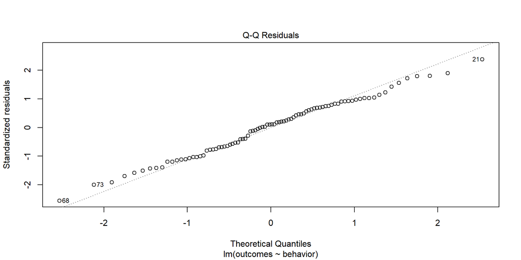

## More Serious Checking to come

```r
plot(check_model(model_one))
```

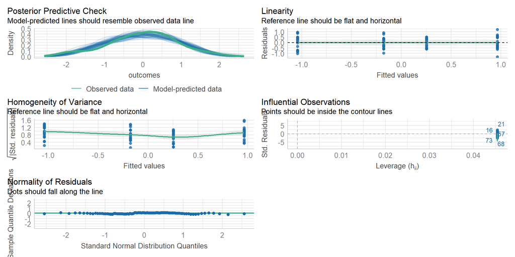

## Do we need to transform?

```r
ggplot(ohio20, aes(sample = outcomes)) +
  geom_qq() + geom_qq_line(col = "red") +
  facet_wrap(~ behavior)
```

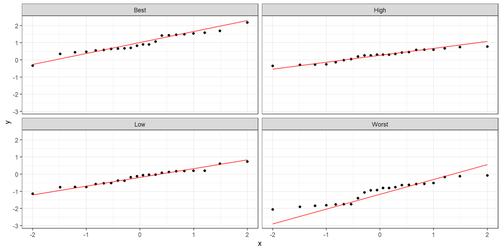

## Transformation?

Would a transformation have been helpful in this setting?

Our model was: `lm(outcomes ~ behavior, data = ohio20)`

```r
ohio20 |> group_by(behavior) |> summarize(min(outcomes))
```

```
# A tibble: 4 × 2
  behavior `min(outcomes)`
  <fct>              <dbl>
1 Best              -0.332
2 High              -0.350
3 Low               -1.15
4 Worst             -2.05
```

- Remember that the Box-Cox method requires our response variable (here `outcomes`) to be strictly positive.

## Does Box-Cox make a suggestion?

```r
ohio20 <- ohio20 |> mutate(out = outcomes + 3)
model2 <- lm(out ~ behavior, data = ohio20)
boxCox(model2)
```

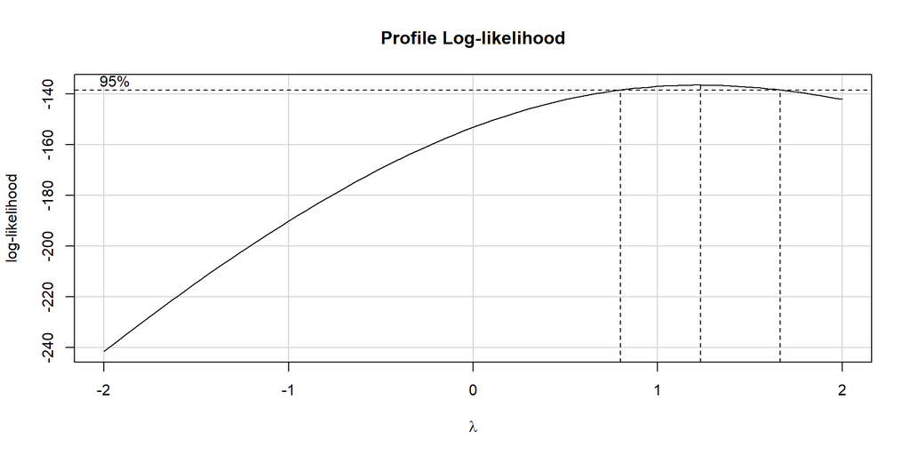

## Can we avoid assuming equal population variances?

Yes, but this isn’t exciting if we have a balanced design.

```r
oneway.test(outcomes ~ behavior, data = ohio20)
```

```
    One-way analysis of means (not assuming equal variances)

data:  outcomes and behavior
F = 43.145, num df = 3.000, denom df = 45.494, p-value = 2.349e-13
```

- Note that this approach uses a fractional degrees of freedom calculation in the denominator.

## The Kruskal-Wallis Test

If you thought the data were severely skewed, you might try:

```r
kruskal.test(outcomes ~ behavior, data = ohio20)
```

```
    Kruskal-Wallis rank sum test

data:  outcomes by behavior
Kruskal-Wallis chi-squared = 61.596, df = 3, p-value = 2.681e-13
```

- $H_0$: The four `behavior` groups have the same center to their `outcomes` distributions.
- $H_A$: At least one group has a shifted distribution, with a different center to its `outcomes`.

What would be the conclusion here?

## Bayesian Linear Model for ANOVA

```r
set.seed(20240919)
model_1b <- stan_glm(outcomes ~ behavior, data = ohio20, refresh = 0)

model_parameters(model_1b, ci = 0.99)
```

```
Parameter     | Median |         99% CI |   pd |  Rhat |     ESS |                     Prior
--------------------------------------------------------------------------------------------
(Intercept)   |   0.97 | [ 0.67,  1.25] | 100% | 1.001 | 1781.00 | Normal (4.09e-11 +- 2.23)
behaviorHigh  |  -0.71 | [-1.11, -0.29] | 100% | 1.000 | 1858.00 |     Normal (0.00 +- 5.11)
behaviorLow   |  -1.14 | [-1.55, -0.74] | 100% | 1.000 | 2230.00 |     Normal (0.00 +- 5.11)
behaviorWorst |  -2.00 | [-2.42, -1.59] | 100% | 1.001 | 2090.00 |     Normal (0.00 +- 5.11)
```

## Again, more serious checking to come

```r
plot(check_model(model_1b))
```

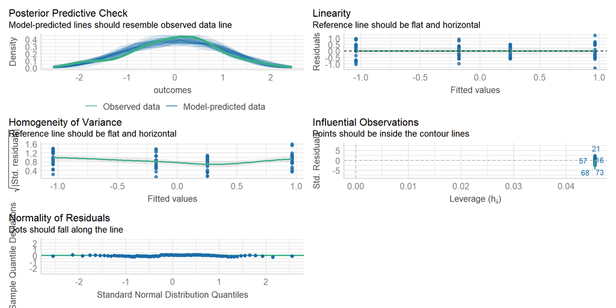

## Estimate Means after Bayesian Fit

```r
estimate_means(model_1b, ci = 0.99)
```

```
Estimated Marginal Means

behavior |  Mean |         99% CI |     pd
------------------------------------------
Best     |  0.97 | [ 0.67,  1.25] |   100%
High     |  0.25 | [-0.04,  0.54] | 98.83%
Low      | -0.18 | [-0.47,  0.13] | 94.00%
Worst    | -1.04 | [-1.34, -0.76] |   100%

Marginal means estimated at behavior
```

## Holm 99% CIs after Bayesian fit

```r
estimate_contrasts(model_1b, ci = 0.99, p_adjust = "Holm")
```

```
Marginal Contrasts Analysis

Level1 | Level2 | Difference |       99% CI |     pd | % in ROPE
----------------------------------------------------------------
Best   |   High |       0.71 | [0.29, 1.11] |   100% |        0%
Best   |    Low |       1.14 | [0.74, 1.55] |   100% |        0%
Best   |  Worst |       2.00 | [1.59, 2.42] |   100% |        0%
High   |    Low |       0.43 | [0.01, 0.85] | 99.52% |        0%
High   |  Worst |       1.29 | [0.90, 1.71] |   100% |        0%
Low    |  Worst |       0.86 | [0.44, 1.31] |   100% |        0%

Marginal contrasts estimated at behavior
```

## Comparison of Holm 99% CIs

```r
con_ols <- as_tibble(estimate_contrasts(model_one, ci = 0.99,
                                        p_adjust = "Holm")) |>
  mutate(contr = str_c(Level1, " - ", Level2))

con_bay <- as_tibble(estimate_contrasts(model_1b, ci = 0.99,
                                        p_adjust = "Holm")) |>
  mutate(contr = str_c(Level1, " - ", Level2))

p1 <- ggplot(con_ols, aes(y = contr, x = Difference)) +
  geom_point(size = 3, color = "firebrick") +
  geom_errorbar(aes(xmin = CI_low, xmax = CI_high)) +
  geom_vline(xintercept = 0, col = "red", lty = "dashed") +
  labs(title = "OLS fit",
    subtitle = "Tukey 99% HSD Intervals for Health Outcomes",
    y = "Contrast", x = "Difference in Health Outcomes Score")

p2 <- ggplot(con_bay, aes(y = contr, x = Difference)) +
  geom_point(size = 3, color = "navy") +
  geom_errorbar(aes(xmin = CI_low, xmax = CI_high)) +
  geom_vline(xintercept = 0, col = "red", lty = "dashed") +
  labs(title = "Bayesian fit",
    subtitle = "Tukey 99% HSD Intervals for Health Outcomes",
    y = "Contrast", x = "Difference in Health Outcomes Score")

p1 + p2
```

## Comparison of Holm 99% CIs

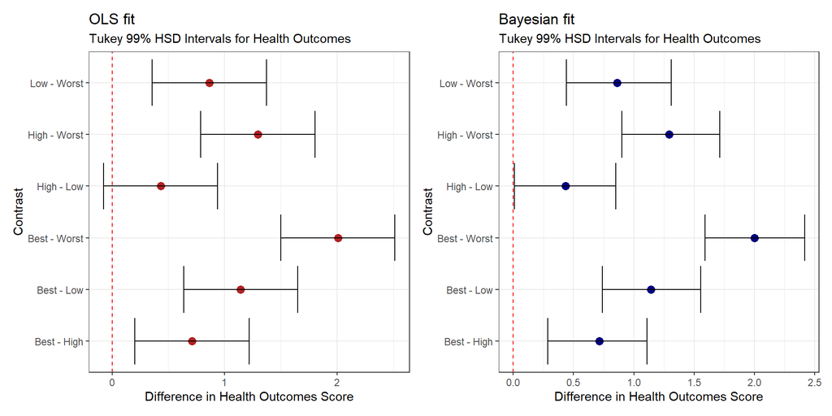

## K Samples: Comparing Means

1. What is the outcome under study?
2. What are the (in this case, $K \geq 2$) treatment/exposure groups?
3. Were the data in fact collected using independent samples?
4. Are the data random samples from the population(s) of interest? Or is there at least a reasonable argument for generalizing from the samples to the population(s)?
5. What is the confidence level we require?
6. Are we doing one-sided or two-sided testing? (usually 2-sided)
7. What does the distribution of each individual sample tell us about which inferential procedure to use?
8. Are there meaningful differences between population means?
9. Can we identify pairwise comparisons of means that show meaningful differences using an appropriate procedure that protects against Type I error expansion due to multiple comparisons?

[figure not shown]

431 Class 08 | 2024-09-19 | https://thomaselove.github.io/431-2024/